# Conservation_glm_md.R

#### Partial pooling & shrinkage in multilevel model

In the **complete pooling** model (i.e. the overall mean) we did not include variation among states, while in the **no pooling** model, we estimated the state means separately, whether literally by separate analyses or in the fixed effects model. In the **partial pooling** model the estimates for the mean in each state are a balance between the information in a state sample and information from other states. To achieve this, we formulate a **multilevel model**. In the multilevel model we consider two levels for means: an overall mean and means for states. Each of the two levels of these means has an associated stochastic process so that there are two variance components, a between-state variance associated with the overall mean and a within-state variance associated with the state means. To fit this model in a frequentist paradigm we can use `lmer()` from the package `lme4`. This model is implicitly a generalized linear mixed model (GLMM) with Normal distribution, identity link, and two levels of stochasticity:

```r
ppfit <- lmer( log_PA_ha ~ 1 + (1|State_Name), REML=FALSE, data=dat1 )
```

The `1` part of the above model specifies the overall mean (the intercept term) while the `+ (1|state)` part specifies that the intercepts for each state should be random variables (more specifically the deviations, or "random effects", of state means from the overall mean will be modeled as a Normally distributed random variable). `REML=FALSE` says to fit by ordinary maximum likelihood rather than the default residual maximum likelihood.

By default, we get limited diagnostics for `lmer()`. Just residuals vs fitted. The residual plot looks good though. We will later explore some other diagnostic options.

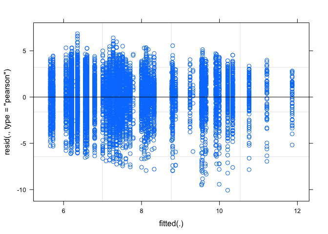

```r
plot(ppfit)
```

In the summary we now see estimates for two levels (or strata) of variance, state (among states) and residual (among counties within states):

```r
summary(ppfit)
```

```
## Linear mixed model fit by maximum likelihood  ['lmerMod']
## Formula: log_PA_ha ~ 1 + (1 | State_Name)
##    Data: dat1
##
##      AIC      BIC   logLik deviance df.resid
##  41255.1  41276.5 -20624.6  41249.1     9162
##
## Scaled residuals:
##     Min      1Q  Median      3Q     Max
## -4.4342 -0.6280  0.1072  0.6952  3.0138
##
## Random effects:
##  Groups     Name        Variance Std.Dev.
##  State_Name (Intercept) 2.385    1.544
##  Residual               5.157    2.271
## Number of obs: 9165, groups:  State_Name, 49
##
## Fixed effects:
##             Estimate Std. Error t value
## (Intercept)   8.0962     0.2238   36.18
```

Plot the fitted model

[figure not shown]

```r
pp_pred_df <- data.frame(coef(ppfit)$State_Name,se.ranef(ppfit)$State_Name[,1],lnPA_mean_var$sample_size_jit)
names(pp_pred_df) <- c("ST_mn","ST_se","sample_size_jit")
pp_mean_df <- data.frame(ovrl_mn=summary(ppfit)$coefficients[1],ovrl_se=summary(ppfit)$coefficients[2])
plotTWO <-
  ggplot(data=pp_pred_df) +
  geom_hline(mapping=aes(yintercept=poolmean),data=cp_pred_df,col="blue") +
  geom_hline(mapping=aes(yintercept=ovrl_mn),data=pp_mean_df,col="blue",lty=2) +
  geom_point(mapping=aes(x=sample_size_jit,y=ST_mn)) +
  geom_linerange(mapping=aes(x=sample_size_jit,ymin=ST_mn-ST_se,ymax=ST_mn+ST_se)) +
  scale_x_continuous(trans="log",breaks=c(1,3,10,30,100)) +
  labs(x="Sample size in State_Name j",y="mean ln(radon) in State_Name j",
       title="Partial pooling: multilevel model, max likelihood")
plotTWO
```

Add a reference point to no pooling and partial pooling plots

```r
plotONE_ref <- plotONE +
  geom_point(mapping=aes(x=sample_size_jit,y=ST_mn),data=np_pred_df[8,],pch=1,cex=10,col="red")


plotTWO_ref <- plotTWO +
  geom_point(mapping=aes(x=sample_size_jit,y=ST_mn),data=pp_pred_df[8,],pch=1,cex=10,col="red")
```

Plot side by side

[figure not shown]

```r
grid.arrange(plotONE_ref, plotTWO_ref, nrow = 1)
```

The right panel is the fitted multilevel model compared to our previous fit of the no pooling model in the left panel. In the multilevel model the estimates for the mean in each state are a balance between the sample mean and the overall mean, depending on the within-state sample size. That is, the information in a particular state is pooled with the information from other states. You can see how this works by comparing the multilevel (partial pooling) model in the right panel to the no pooling model in the left panel. If there are more observations for a given state, there is more information at the state level, so the estimate of the state mean in the multilevel model remains close to the sample mean. If there are fewer observations, information from the other states will pull an estimate for a particular state toward the overall mean, like state 8 (DC), which is circled in red. This is called **shrinkage**. In this case, it moves upward when shrinking, because it is lower than the overall mean. The other thing to note is the dashed blue line. This is the estimated overall mean from the multilevel model, which is also a balance of the information at different levels. You can see that it is higher than simply the overall mean of the data (solid blue line). #### Partial pooling, Bayesian fit of multilevel model